# Recitation 10

Anique Tahir

## Outline

- Box and Circle Diagrams
- l-values and r-values
- Assignment and Pointer Semantics

## Box and Circle Diagram

[figure not shown]

## Copy Semantics

```
x=y
```

```
x=5
```

Copy the value in the location associated with y to the location associated with x

Copy the value 5 to the location associated with x

## l-values

- Values which have a location associated with them

e.g.

x, x[i]

## r-values

- Values which do not have a location association

e.g.

5, x+y, foo(), foo() + 5

## l-value and r-value assignments

l-value = l-value

l-value = r-value

r-value = l-value ❌

r-value = r-value ❌

```python
%load_ext hierarchymagic
```

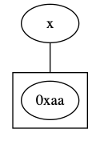

```python
%%dot
digraph D {
    compound=true;
    subgraph cluster1 {
      e[label="0xaa"];
    }
    x->e [lhead=cluster1, arrowhead=none];
}
```

## Pointer Semantics

```
T * x;
```

x is a **pointer** to a T value

```
T ** x;
```

x is a pointer to a T* value

x is a pointer to a pointer to a T value

## malloc

Used to assign space on the heap

```
T * x = (T *) malloc(sizeof T)
```

Output of malloc is an R-Value

## Address Operator (&)

- Operand: l-value
- Output: r-value

## Dereference Operator (*)

- Operand: l-value or r-value
- Result: l-value

## &/* Example (From Typed Notes)

```
int x;
int* y;

y = &x;

y = &*y;

y = *&y;

x = 1;

y = (int*) malloc(sizeof(int));

*y = x;
```

## Structs

- The members of a structs are located in contiguous areas of memory

  ```
  struct{
    int i, j;
  } x;
  ```

## Arrays

Arrays are just like pointers

```
int x[]
```

Similar to

```
int* x
```

Pointers and arrays can be used interchangably

```
*(x+y)
```

and

```
x[y]
```

are the same

## Pointers and Structs

```
struct st{
    inti;
    struct st* next;
} * x;
```

## Aliases

```
Two expressions are aliases of each other if they have the same location associated with them.
```

-Typed Notes

Categories of aliases:

- pointers
- arrays
- pass by reference
- assignment with reference

## Dangling References

- When memory related to a variable is freed but some variable points to that part of memory

## Garbage Values

- When memory has been allocated for some value but it is never freed

## Exercise

What is the difference between Dangling References and Garbage Values?